# Tugas Praktikum 3 MPDW: Model Regresi dengan Peubah Lag

# Packages

```r
library(dLagM)
```

```r
library(dynlm) #data harus timeseries
library(MLmetrics) #MAPE
library(lmtest)
library(car)
library(zoo)
library(dplyr)
library(readxl)
library(readr)
```

# Data

```r
data <- read_xlsx("C:\\Users\\LENOVO\\Downloads\\data_sales_advertising.xlsx")
str(data)
```

```
## tibble [40 × 3] (S3: tbl_df/tbl/data.frame)
##  $ Year       : num [1:40] 1975 1976 1977 1978 1979 ...
##  $ Sales      : num [1:40] 11.7 12 12.3 12.8 13.1 13.6 13.9 14.4 14.7 15.3 ...
##  $ Advertising: num [1:40] 9.4 9.6 10 10.4 10.8 10.9 11.7 12.2 12.5 12.9 ...
```

```r
head(data)
```

```
## # A tibble: 6 × 3
##    Year Sales Advertising
##   <dbl> <dbl>       <dbl>
## 1  1975  11.7         9.4
## 2  1976  12           9.6
## 3  1977  12.3        10
## 4  1978  12.8        10.4
## 5  1979  13.1        10.8
## 6  1980  13.6        10.9
```

```r
t <- data$Year
t <- tibble::num(1:32)
xt <- data$`Advertising`
yt <- data$Sales
xt <- as.vector(xt)
yt <- as.vector(yt)
```

```r
data1 <- cbind(t, xt, yt)
data1 <- as.data.frame(data1)
str(data1)
```

```
## 'data.frame':    40 obs. of  3 variables:
##  $ t : num  1 2 3 4 5 6 7 8 9 10 ...
##  $ xt: num  9.4 9.6 10 10.4 10.8 10.9 11.7 12.2 12.5 12.9 ...
##  $ yt: num  11.7 12 12.3 12.8 13.1 13.6 13.9 14.4 14.7 15.3 ...
```

```r
head(data1)
```

```
##   t   xt   yt
## 1 1  9.4 11.7
## 2 2  9.6 12.0
## 3 3 10.0 12.3
## 4 4 10.4 12.8
## 5 5 10.8 13.1
## 6 6 10.9 13.6
```

```r
#SPLIT DATA
train<-data1[1:32,]
test<-data1[33:40,]
train <- as.data.frame(train)
test <- as.data.frame(test)
```

```r
#data time series
train.ts<-ts(train)
test.ts<-ts(test)
data.ts<-ts(data1)
```

# Eksplorasi Data

## Plot Time Series

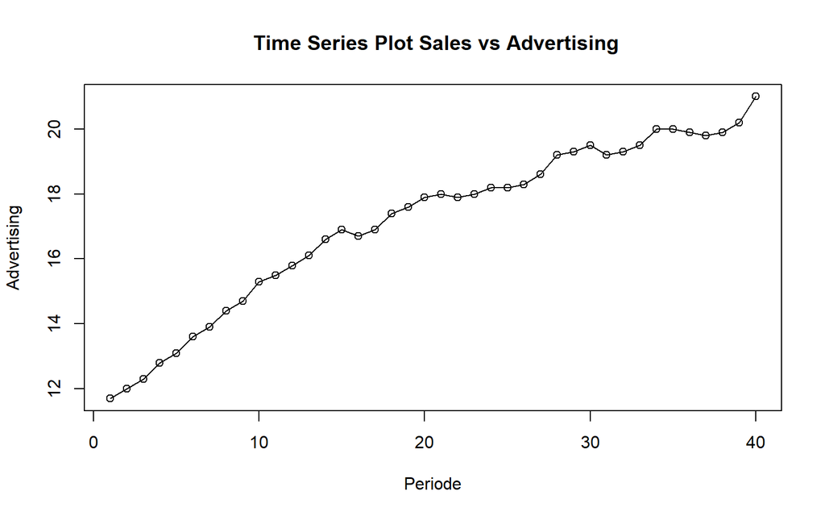

```r
data.ts1 <- ts(yt)
plot(data.ts1, main = " Time Series Plot Sales vs Advertising", xlab = "Periode", ylab ="Advertising")
points(data.ts1)
```

## Korelasi Peubah X dan Y

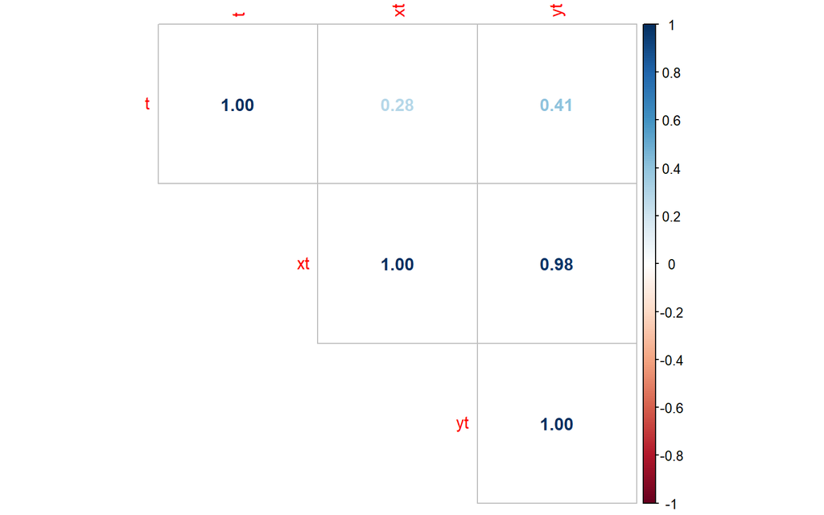

```r
corrplot::corrplot(corr=cor(data1), method="number", type="upper")
```

```r
cor(xt, yt)
```

```
## [1] 0.9795849
```

## Scatter Plot X dan Y

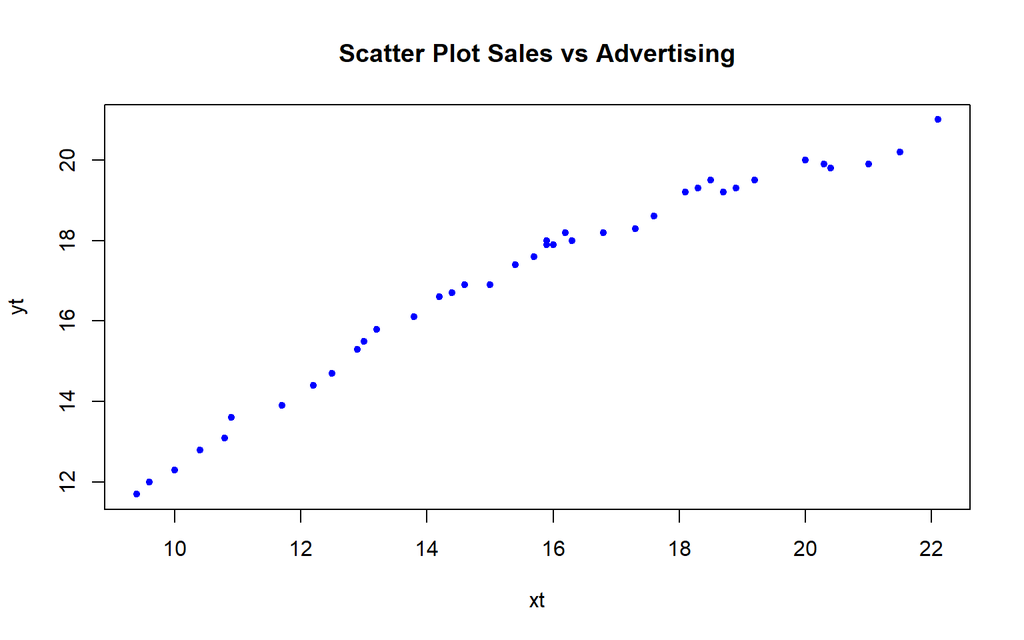

```r
plot(xt, yt, pch = 20, col = "blue", main = "Scatter Plot Sales vs Advertising")
```

# Model KOYCK

## Pemodelan KOYCK

```r
model.koyck <- dLagM :: koyckDlm(x=train$xt , y =train$yt)
summary(model.koyck)
```

```
##
## Call:
## "Y ~ (Intercept) + Y.1 + X.t"
##
## Residuals:
##      Min       1Q   Median       3Q      Max
## -0.42880 -0.09790 -0.01132  0.09751  0.38616
##
## Coefficients:
##             Estimate Std. Error t value Pr(>|t|)
## (Intercept)  1.41668    0.43419   3.263   0.0029 **
## Y.1          0.84065    0.10190   8.250  5.6e-09 ***
## X.t          0.09730    0.08718   1.116   0.2739
## ---
## Signif. codes:  0 '***' 0.001 '**' 0.01 '*' 0.05 '.' 0.1 ' ' 1
##
## Residual standard error: 0.1818 on 28 degrees of freedom
## Multiple R-Squared: 0.9939,  Adjusted R-squared: 0.9935
## Wald test:  2292 on 2 and 28 DF,  p-value: < 2.2e-16
##
## Diagnostic tests:
## NULL
##
##                            alpha       beta       phi
## Geometric coefficients:  8.89017 0.09729997 0.8406466
```

## AIC dan BIC

```r
AIC(model.koyck)
```

```
## [1] -12.89328
```

```r
BIC(model.koyck)
```

```
## [1] -7.157335
```

## Forecasting

```r
#ramalan
(fore.koyck <- forecast(model = model.koyck, x=test$xt, h=nrow(test)))
```

```
## $forecasts
## [1] 19.50932 19.76312 19.97648 20.18503 20.37007 20.58401 20.81251 21.06297
##
## $call
## forecast.koyckDlm(model = model.koyck, x = test$xt, h = nrow(test))
##
## attr(,"class")
## [1] "forecast.koyckDlm" "dLagM"
```

## Akurasi

```r
mape.koyck <- MAPE(fore.koyck$forecasts, test$yt)
mape.koyck #data test
```

```
## [1] 0.01553823
```

```r
#akurasi data training
GoF(model.koyck)
```

```
##              n       MAE           MPE        MAPE      sMAPE      MASE
## model.koyck 31 0.1342519 -0.0001867148 0.008178547 0.00817584 0.4738303
##                    MSE     MRAE    GMRAE
## model.koyck 0.02984154 50362273 0.753862
```

# Regression with Distributed Lag

## Pemodelan Regression with Distributed Lag (Lag = 2)

```r
model.dlm = dLagM::dlm(x = train$xt,y = train$yt , q = 2)
summary(model.dlm)
```

```
##
## Call:
## lm(formula = model.formula, data = design)
##
## Residuals:
##      Min       1Q   Median       3Q      Max
## -0.66716 -0.15331  0.05975  0.21779  0.49109
##
## Coefficients:
##             Estimate Std. Error t value Pr(>|t|)
## (Intercept)   5.3117     0.4096  12.968 7.37e-13 ***
## x.t           0.2014     0.2899   0.695    0.493
## x.1           0.4296     0.3728   1.152    0.260
## x.2           0.1523     0.2811   0.542    0.593
## ---
## Signif. codes:  0 '***' 0.001 '**' 0.01 '*' 0.05 '.' 0.1 ' ' 1
##
## Residual standard error: 0.3247 on 26 degrees of freedom
## Multiple R-squared:  0.9791, Adjusted R-squared:  0.9767
## F-statistic: 405.4 on 3 and 26 DF,  p-value: < 2.2e-16
##
## AIC and BIC values for the model:
##        AIC      BIC
## 1 23.36095 30.36694
```

## AIC dan BIC

```r
AIC(model.dlm)
```

```
## [1] 23.36095
```

```r
BIC(model.dlm)
```

```
## [1] 30.36694
```

## Peramalan dan Akurasi

```r
fore.dlm <- forecast(model = model.dlm, x=test$xt, h=8)
fore.dlm
```

```
## $forecasts
## [1] 20.14394 20.46435 20.85369 21.03589 21.18490 21.39435 21.76800 22.19496
##
## $call
## forecast.dlm(model = model.dlm, x = test$xt, h = 8)
##
## attr(,"class")
## [1] "forecast.dlm" "dLagM"
```

```r
mape.dlm <- MAPE(fore.dlm$forecasts, test$yt)
mape.dlm
```

```
## [1] 0.05444612
```

```r
#akurasi data training
GoF(model.dlm)
```

```
##            n      MAE           MPE       MAPE     sMAPE      MASE        MSE
## model.dlm 30 0.250373 -0.0006085903 0.01536926 0.0153258 0.8854654 0.09139979
##               MRAE    GMRAE
## model.dlm 22272733 1.596656
```

## Lag Optimum

```r
#penentuan lag optimum
finiteDLMauto(formula = yt ~ xt,
              data = data.frame(train), q.min = 1, q.max = 5 ,
              model.type = "dlm", error.type = "AIC", trace = TRUE) ##q max lag maksimum
```

```
##   q - k    MASE      AIC      BIC   GMRAE    MBRAE R.Adj.Sq    Ljung-Box
## 5     5 0.74805 16.63242 26.99912 1.24971  1.06597  0.97305 1.120254e-03
## 4     4 0.78565 20.35187 29.67731 1.31640 -0.06124  0.97311 6.468981e-04
## 3     3 0.83537 21.14425 29.34803 1.49169 -0.24182  0.97552 1.392205e-04
## 2     2 0.88547 23.36095 30.36694 1.59666  0.48600  0.97666 7.896936e-05
## 1     1 0.95109 24.88267 30.61861 1.59217  4.14910  0.97801 2.148961e-05
```

```r
#model dlm dengan lag optimum
model.dlm2 = dLagM::dlm(x = train$xt,y = train$yt , q = 1) #terdapat lag yang tidak signifikan sehingga dapat dikurangi jumlah lagnya
summary(model.dlm2)
```

```
##
## Call:
## lm(formula = model.formula, data = design)
##
## Residuals:
##      Min       1Q   Median       3Q      Max
## -0.69277 -0.23966  0.08151  0.22400  0.46735
##
## Coefficients:
##             Estimate Std. Error t value Pr(>|t|)
## (Intercept)   4.9536     0.3577  13.849 4.72e-14 ***
## x.t           0.3194     0.2905   1.100    0.281
## x.1           0.4814     0.2862   1.682    0.104
## ---
## Signif. codes:  0 '***' 0.001 '**' 0.01 '*' 0.05 '.' 0.1 ' ' 1
##
## Residual standard error: 0.3343 on 28 degrees of freedom
## Multiple R-squared:  0.9795, Adjusted R-squared:  0.978
## F-statistic: 668.1 on 2 and 28 DF,  p-value: < 2.2e-16
##
## AIC and BIC values for the model:
##        AIC      BIC
## 1 24.88267 30.61861
```

## AIC dan BIC

```r
AIC(model.dlm2)
```

```
## [1] 24.88267
```

```r
BIC(model.dlm2)
```

```
## [1] 30.61861
```

## Akurasi dan Peramalan

```r
#peramalan dan akurasi
fore.dlm2 <- forecast(model = model.dlm2, x=test$xt, h=8)

#akurasi data test
mape.dlm2<- MAPE(fore.dlm2$forecasts, test$yt)
mape.dlm2
```

```
## [1] 0.05929172
```

```r
#akurasi data training
GoF(model.dlm2)
```

```
##             n       MAE           MPE       MAPE      sMAPE     MASE       MSE
## model.dlm2 31 0.2694741 -0.0007066841 0.01664761 0.01659905 0.951085 0.1009354
##                MRAE    GMRAE
## model.dlm2 27169184 1.592174
```

# Model Autoregressive / Dynamic Regression

## Pemodelan Model Autoregressive

```r
#MODEL AUTOREGRESSIVE
#library(dLagM)
model.ardl = ardlDlm(x = train$xt, y = train$yt, p = 1 , q = 1) #p:lag x, q:lag y
#model untuk p=1, q=1: yt=b0+b1yt-1+b2xt+b3xt-1
#model untuk p=2, q=3: yt=b0+b1yt-1+b2yt-2+b3xt+b4xt-1+b5xt-2

summary(model.ardl)
```

```
##
## Time series regression with "ts" data:
## Start = 2, End = 32
##
## Call:
## dynlm(formula = as.formula(model.text), data = data, start = 1)
##
## Residuals:
##      Min       1Q   Median       3Q      Max
## -0.42212 -0.13934  0.00585  0.09313  0.33270
##
## Coefficients:
##             Estimate Std. Error t value Pr(>|t|)
## (Intercept)  1.30304    0.47500   2.743   0.0107 *
## X.t          0.30844    0.15564   1.982   0.0578 .
## X.1         -0.20644    0.17382  -1.188   0.2453
## Y.1          0.83951    0.09995   8.399  5.2e-09 ***
## ---
## Signif. codes:  0 '***' 0.001 '**' 0.01 '*' 0.05 '.' 0.1 ' ' 1
##
## Residual standard error: 0.1791 on 27 degrees of freedom
## Multiple R-squared:  0.9943, Adjusted R-squared:  0.9937
## F-statistic:  1575 on 3 and 27 DF,  p-value: < 2.2e-16
```

## AIC dan BIC

```r
AIC(model.ardl)
```

```
## [1] -12.93737
```

```r
BIC(model.ardl)
```

```
## [1] -5.767436
```

```r
model.ardl <- ardlDlm(formula = yt ~ xt,
                         data = train,p = 1 , q = 1)
summary(model.ardl)
```

```
##
## Time series regression with "ts" data:
## Start = 2, End = 32
##
## Call:
## dynlm(formula = as.formula(model.text), data = data)
##
## Residuals:
##      Min       1Q   Median       3Q      Max
## -0.42212 -0.13934  0.00585  0.09313  0.33270
##
## Coefficients:
##             Estimate Std. Error t value Pr(>|t|)
## (Intercept)  1.30304    0.47500   2.743   0.0107 *
## xt.t         0.30844    0.15564   1.982   0.0578 .
## xt.1        -0.20644    0.17382  -1.188   0.2453
## yt.1         0.83951    0.09995   8.399  5.2e-09 ***
## ---
## Signif. codes:  0 '***' 0.001 '**' 0.01 '*' 0.05 '.' 0.1 ' ' 1
##
## Residual standard error: 0.1791 on 27 degrees of freedom
## Multiple R-squared:  0.9943, Adjusted R-squared:  0.9937
## F-statistic:  1575 on 3 and 27 DF,  p-value: < 2.2e-16
```

```r
AIC(model.ardl)
```

```
## [1] -12.93737
```

```r
BIC(model.ardl)
```

```
## [1] -5.767436
```

## Ramalan dan Akurasi

```r
fore.ardl <- forecast(model = model.ardl, x=test$xt, h=8)
fore.ardl
```

```
## $forecasts
## [1] 19.52586 19.90030 20.04949 20.26727 20.41900 20.71081 20.98614 21.29912
##
## $call
## forecast.ardlDlm(model = model.ardl, x = test$xt, h = 8)
##
## attr(,"class")
## [1] "forecast.ardlDlm" "dLagM"
```

```r
mape.ardl <- MAPE(fore.ardl$forecasts, test$yt)
mape.ardl
```

```
## [1] 0.01905123
```

```r
#akurasi data training
GoF(model.ardl)
```

```
##             n       MAE          MPE        MAPE       sMAPE      MASE
## model.ardl 31 0.1351188 -0.000172352 0.008225628 0.008223183 0.4768899
##                   MSE     MRAE     GMRAE
## model.ardl 0.02793731 73180231 0.7094915
```

## Lag Optimum

```r
data <- data.frame(
  yt = data$`Advertising`,
  xt = data$Sales
)

model.ardl.opt <- ardlBoundOrders(
  data = data,
  ic = "AIC",
  formula = yt ~ xt
)

model.ardl.opt
```

```
## $p
##   xt
## 1 12
##
## $q
## [1] 9
##
## $Stat.table
##              q = 1       q = 2       q = 3       q = 4      q = 5       q = 6
## p = 1   -8.6142986  -7.1403595   -6.101253  -3.3282081  -8.676386  -5.9450110
## p = 2   -6.7574697  -5.5841974   -4.106221  -1.3728528  -7.484360  -4.6461001
## p = 3   -3.5664966  -3.5664966   -2.327190   0.6232537  -5.489275  -2.6618283
## p = 4   -0.9549652   0.6182870    0.618287   2.4334470  -3.704607  -0.7733147
## p = 5   -5.3191258  -4.4894902   -3.063684  -3.0636844  -1.714718   0.9215575
## p = 6   -6.3737715  -5.0420545   -3.936807  -2.0554661  -2.055466  -0.4053953
## p = 7   -1.0236206   0.2061001    1.039486   2.6643231   3.264271   3.2642712
## p = 8   -8.8818638  -7.0008091   -5.542688  -3.5486459  -2.399766  -3.8397735
## p = 9    1.2263235   3.0990556    4.340310   6.2688291   7.890410   9.4512896
## p = 10   1.7950615   2.5900779    4.580496   6.5632736   8.039547   9.6341127
## p = 11  -3.8013155  -2.2153968   -1.390018   0.2686377   1.506452   3.5064421
## p = 12  -5.4199174  -4.2333748   -3.391685  -1.5895960 -13.015242 -11.0858373
## p = 13   1.0141344   2.1812117   -2.054417  -0.6830391 -26.854404 -26.1023709
## p = 14  -2.0127948  -6.8797922  -10.011180 -13.5059156 -12.978762          NA
## p = 15 -19.0762606 -61.4031109 -101.781832          NA         NA          NA
##              q = 7        q = 8         q = 9     q = 10       q = 11
## p = 1   -7.9768841  -6.53800488   -2.53352583  0.7463506    0.1874521
## p = 2   -7.7846903  -6.70151042   -3.18412212  0.3255141   -4.4853470
## p = 3   -5.8124917  -5.41858352   -2.38433912  0.8369595   -5.1497179
## p = 4   -3.8125061  -3.41894349   -0.48045595  2.7492672   -3.4942934
## p = 5   -5.2518741  -4.11218296   -0.83597737  2.4613115   -1.6784777
## p = 6   -3.2799705  -3.53714097   -0.24021255  2.7902378   -0.3902234
## p = 7   -6.5265866  -4.05669376   -4.63642347 -2.0053981   -3.9492578
## p = 8   -3.8397735  -2.28543977   -4.85091487 -3.1327137   -7.4613168
## p = 9    0.8737420   0.87374197   -3.54802898 -2.7517239  -15.6461196
## p = 10   0.5315777  -0.05638197   -0.05638197 -1.7895480  -14.0751698
## p = 11  -5.9068046  -3.99460628   -4.12756583 -4.1275658 -100.2488935
## p = 12 -15.3031717 -17.51351982 -181.36933881         NA           NA
## p = 13 -44.0010181           NA            NA         NA           NA
## p = 14          NA           NA            NA         NA           NA
## p = 15          NA           NA            NA         NA           NA
##             q = 12     q = 13     q = 14     q = 15
## p = 1    3.4599219  2.7851740   3.141541  -14.06847
## p = 2   -0.2437452  1.0972395   3.438798  -29.76702
## p = 3   -0.8236333 -0.6672987   1.883941  -33.31994
## p = 4    0.8578603  0.8227559   1.456750 -129.79942
## p = 5    2.6340708  2.8219336  -5.270580         NA
## p = 6    3.9529182  4.2982463 -98.053883         NA
## p = 7   -0.3275319 -1.8887654         NA         NA
## p = 8   -3.1027415 -6.4847956         NA         NA
## p = 9  -16.2349447         NA         NA         NA
## p = 10 -22.5319417         NA         NA         NA
## p = 11          NA         NA         NA         NA
## p = 12          NA         NA         NA         NA
## p = 13          NA         NA         NA         NA
## p = 14          NA         NA         NA         NA
## p = 15          NA         NA         NA         NA
##
## $min.Stat
## [1] -181.3693
```

```r
min_p=c()
for(i in 1:6){
  min_p[i]=min(model.ardl.opt$Stat.table[[i]])
}
q_opt=which(min_p==min(min_p, na.rm = TRUE))
p_opt=which(model.ardl.opt$Stat.table[[q_opt]] ==
              min(model.ardl.opt$Stat.table[[q_opt]], na.rm = TRUE))
data.frame("q_optimum" = q_opt, "p_optimum" = p_opt,
           "AIC"=model.ardl.opt$min.Stat)
```

```
##   q_optimum p_optimum       AIC
## 1         3        15 -181.3693
```

# Pemodelan DLM & ARDL dengan Library dynlm

```r
#sama dengan model dlm q=1
cons_lm1 <- dynlm(yt ~ xt+L(xt),data = train.ts)

#sama dengan model ardl p=1 q=0
cons_lm2 <- dynlm(yt ~ xt+L(yt),data = train.ts)

#sama dengan ardl p=1 q=1
cons_lm3 <- dynlm(yt ~ xt+L(xt)+L(yt),data = train.ts)

#sama dengan dlm p=2
cons_lm4 <- dynlm(yt ~ xt+L(xt)+L(xt,2),data = train.ts)
```

## Ringkasan Model

```r
summary(cons_lm1)
```

```
##
## Time series regression with "ts" data:
## Start = 2, End = 32
##
## Call:
## dynlm(formula = yt ~ xt + L(xt), data = train.ts)
##
## Residuals:
##      Min       1Q   Median       3Q      Max
## -0.69277 -0.23966  0.08151  0.22400  0.46735
##
## Coefficients:
##             Estimate Std. Error t value Pr(>|t|)
## (Intercept)   4.9536     0.3577  13.849 4.72e-14 ***
## xt            0.3194     0.2905   1.100    0.281
## L(xt)         0.4814     0.2862   1.682    0.104
## ---
## Signif. codes:  0 '***' 0.001 '**' 0.01 '*' 0.05 '.' 0.1 ' ' 1
##
## Residual standard error: 0.3343 on 28 degrees of freedom
## Multiple R-squared:  0.9795, Adjusted R-squared:  0.978
## F-statistic: 668.1 on 2 and 28 DF,  p-value: < 2.2e-16
```

```r
summary(cons_lm2)
```

```
##
## Time series regression with "ts" data:
## Start = 2, End = 32
##
## Call:
## dynlm(formula = yt ~ xt + L(yt), data = train.ts)
##
## Residuals:
##      Min       1Q   Median       3Q      Max
## -0.44535 -0.12936  0.01316  0.09604  0.34783
##
## Coefficients:
##             Estimate Std. Error t value Pr(>|t|)
## (Intercept)  1.62423    0.39336   4.129 0.000297 ***
## xt           0.14660    0.07575   1.935 0.063131 .
## L(yt)        0.78358    0.08881   8.824 1.41e-09 ***
## ---
## Signif. codes:  0 '***' 0.001 '**' 0.01 '*' 0.05 '.' 0.1 ' ' 1
##
## Residual standard error: 0.1804 on 28 degrees of freedom
## Multiple R-squared:  0.994,  Adjusted R-squared:  0.9936
## F-statistic:  2328 on 2 and 28 DF,  p-value: < 2.2e-16
```

```r
summary(cons_lm3)
```

```
##
## Time series regression with "ts" data:
## Start = 2, End = 32
##
## Call:
## dynlm(formula = yt ~ xt + L(xt) + L(yt), data = train.ts)
##
## Residuals:
##      Min       1Q   Median       3Q      Max
## -0.42212 -0.13934  0.00585  0.09313  0.33270
##
## Coefficients:
##             Estimate Std. Error t value Pr(>|t|)
## (Intercept)  1.30304    0.47500   2.743   0.0107 *
## xt           0.30844    0.15564   1.982   0.0578 .
## L(xt)       -0.20644    0.17382  -1.188   0.2453
## L(yt)        0.83951    0.09995   8.399  5.2e-09 ***
## ---
## Signif. codes:  0 '***' 0.001 '**' 0.01 '*' 0.05 '.' 0.1 ' ' 1
##
## Residual standard error: 0.1791 on 27 degrees of freedom
## Multiple R-squared:  0.9943, Adjusted R-squared:  0.9937
## F-statistic:  1575 on 3 and 27 DF,  p-value: < 2.2e-16
```

```r
summary(cons_lm4)
```

```
##
## Time series regression with "ts" data:
## Start = 3, End = 32
##
## Call:
## dynlm(formula = yt ~ xt + L(xt) + L(xt, 2), data = train.ts)
##
## Residuals:
##      Min       1Q   Median       3Q      Max
## -0.66716 -0.15331  0.05975  0.21779  0.49109
##
## Coefficients:
##             Estimate Std. Error t value Pr(>|t|)
## (Intercept)   5.3117     0.4096  12.968 7.37e-13 ***
## xt            0.2014     0.2899   0.695    0.493
## L(xt)         0.4296     0.3728   1.152    0.260
## L(xt, 2)      0.1523     0.2811   0.542    0.593
## ---
## Signif. codes:  0 '***' 0.001 '**' 0.01 '*' 0.05 '.' 0.1 ' ' 1
##
## Residual standard error: 0.3247 on 26 degrees of freedom
## Multiple R-squared:  0.9791, Adjusted R-squared:  0.9767
## F-statistic: 405.4 on 3 and 26 DF,  p-value: < 2.2e-16
```

# SSE

```r
deviance(cons_lm1)
```

```
## [1] 3.128996
```

```r
deviance(cons_lm2)
```

```
## [1] 0.9113055
```

```r
deviance(cons_lm3)
```

```
## [1] 0.8660565
```

```r
deviance(cons_lm4)
```

```
## [1] 2.741994
```

Berdasarkan output di atas, model yang memiliki nilai SSE terendah yaitu cons_lm3

# Uji Encomptest

```r
#uji model
if(require("lmtest")) encomptest(cons_lm1, cons_lm2)
```

```
## Encompassing test
##
## Model 1: yt ~ xt + L(xt)
## Model 2: yt ~ xt + L(yt)
## Model E: yt ~ xt + L(xt) + L(yt)
##           Res.Df Df       F    Pr(>F)
## M1 vs. ME     27 -1 70.5489 5.199e-09 ***
## M2 vs. ME     27 -1  1.4107    0.2453
## ---
## Signif. codes:  0 '***' 0.001 '**' 0.01 '*' 0.05 '.' 0.1 ' ' 1
```

## Uji Autokorelasi Residual

```r
#durbin watson
dwtest(cons_lm1)
```

```
##
##  Durbin-Watson test
##
## data:  cons_lm1
## DW = 0.29644, p-value = 1.431e-11
## alternative hypothesis: true autocorrelation is greater than 0
```

```r
#durbin watson
dwtest(cons_lm2)
```

```
##
##  Durbin-Watson test
##
## data:  cons_lm2
## DW = 1.793, p-value = 0.173
## alternative hypothesis: true autocorrelation is greater than 0
```

```r
#durbin watson
dwtest(cons_lm3)
```

```
##
##  Durbin-Watson test
##
## data:  cons_lm3
## DW = 2.0428, p-value = 0.4089
## alternative hypothesis: true autocorrelation is greater than 0
```

```r
#durbin watson
dwtest(cons_lm4)
```

```
##
##  Durbin-Watson test
##
## data:  cons_lm4
## DW = 0.34261, p-value = 4.098e-10
## alternative hypothesis: true autocorrelation is greater than 0
```

Berdasarkan hasil Durbin-Watson test dengan taraf signifikansi α = 0,05, model cons_lm1 memiliki p-value sebesar 1,431 × 10⁻¹¹ < 0,05 dan model cons_lm4 memiliki p-value sebesar 4,098 × 10⁻¹⁰ < 0,05, sehingga H₀ ditolak. Artinya, pada model cons_lm1 dan cons_lm4 terdapat autokorelasi positif pada residual.

Sementara itu, model cons_lm2 memiliki p-value = 0,173 > 0,05 dan model cons_lm3 memiliki p-value = 0,4089 > 0,05, sehingga H₀ tidak ditolak. Artinya, tidak terdapat bukti yang cukup untuk menyatakan adanya autokorelasi positif pada residual kedua model tersebut.

Dengan demikian, model cons_lm2 dan cons_lm3 memenuhi asumsi non-autokorelasi, sedangkan cons_lm1 dan cons_lm4 tidak memenuhi asumsi tersebut.